# **COMPARATIVA DE LA ESPÍCULA EN DELTA Y ÓMICRON**

Análisis de Biología Computacional

05 de Mayo del 2022

### Integrantes:

- A01424709, Armando Arredondo Valle
- A01424731, Aldo Olascoaga Olmedo
- A01423655, Diego Efraín Antonio Pérez

## **Introducción**

En este proyecto, se busca saber así como analizar las variantes de interés Ómicron y Delta, buscando ver si es que cumplen con ciertas características así como un número específico de mutaciones, las cuales afectan de forma directa al organismo del cuerpo humano.

Tanto Ómicron como Delta son variantes de interés, las cuales estuvieron en su pleno auge en su mayoría durante el año 2021, este año fue uno de los años con mayor tasa de crecimiento de la pandemia así como lo que muchos llaman el punto de quiebre de la misma a finales del mismo año.

[figure not shown]

Cabe recalcar, que para hacer el análisis de de cada una de las variantes, fue necesario realizar la alineación de ambas, esto con base a que ambas variantes tenían diferentes tamaños en su espícula, es por ello que utilizando código (previamente visto en clase), realizamos la alineación de ambas.

## **Objetivo**

El objetivo de este proyecto es hacer un análisis parcial de las variantes Ómicron y Delta, para poder así llegar a un posible restultado del porqué es que una es más contagiosa que otra, y por qué una representó un mayor peligro a nivel mundial.

## **Hipótesis**

Con este proyecto su busca demostrar la estrecha relación que hay entre el número de mutaciones encontradas en la espícula de la variante Ómicron y su formidable capacidad de infección en humanos, además de proporcionar una gran carga viral entre los individuos infectados.

## **Marco teórico**

#### **¿Qué es el virus Sars-Cov2?**

Los coronavirus son una familia de virus que causan enfermedades (desde el resfriado común hasta enfermedades respiratorias más graves) y circulan entre humanos y animales.

##### **Información de la variante Ómicron**

- Ómicron es de dos a cuatro veces más contagiosa que Delta.
- Ómicron es más eficiente al evadir anticuerpos proporcionados por las actuales vacunas.
- Ómicron cuenta con aproximadamente 36 mutaciones en su espícula.
- Debido a un gran número de mutaciones en el RBD, la variante Ómicron es mucho más transmisible que Delta.
- Un dominio de unión al receptor (RBD) es una parte clave de un virus ubicado en su dominio de “espícula” que le permite acoplarse a los receptores del cuerpo para ingresar a las células y provocar una infección.

##### **Información de la variante Delta**

- La variante Delta fue detectada por primera vez en la India en diciembre de 2020.
- Se determinó que Delta fue 2 veces más contagiosa que la variante original de Wuhan.
- La carga viral de Delta era bastante elevada en personas contagiadas con esta variante.
- Delta fue la variante del SARS-CoV-2 que dominó al mundo hasta finales de 2021.
- Las mutaciones en el receptor RBD impactaron de manera significativa a la hora de evadir cierta inmunidad por parte de los infectados.

## **Experimentación**

Para poder realizar este proyecto, fue necesario hacer la modificación necesaria a los archivos FASTA.

Es por ello que hicimos el cambio de ADN a ARN para poder hacer así una mejor comparativa de los datos.

**Función para realizar la traducción:**

```r
  # Realizamos aquí la parte de cambiar a mayúsculas las partes de la secuencia
  A = toupper(Delta[[1]])[1:100]
  B = toupper(Omicron[[1]])[1:100]
  # Función para el cambio a realizar:
  ADN_to_ARNm = function(nucleotido){
    return (switch(nucleotido,"C"="G","G"="C","T"="A","A"="U"))
  }
  # Ejecutamos la función dentro de A y B
  A = as.vector(sapply(A, ADN_to_ARNm))
  B = as.vector(sapply(B, ADN_to_ARNm))
```

##### Análisis de los archivos FASTA

**Análisis de la variante Ómicron después de hacer la alineación**

```
  [1] "A" "U" "G" "U" "U" "U" "G" "U" "U" "U" "U" "U" "C" "U" "U" "G" "U" "U" "U" "U"
 [21] "A" "U" "U" "G" "C" "C" "A" "C" "U" "A" "G" "U" "C" "U" "C" "U" "A" "G" "U" "C"
 [41] "A" "G" "U" "G" "U" "G" "U" "U" "A" "A" "U" "C" "U" "U" "A" "G" "A" "A" "C" "C"
 [61] "A" "G" "A" "A" "C" "U" "C" "A" "A" "U" "U" "A" "C" "C" "C" "C" "C" "U" "G" "C"
 [81] "A" "U" "A" "C" "A" "C" "U" "A" "A" "U" "U" "C" "U" "U" "U" "C" "A" "C" "A" "C"
[101] "_"
```

**Análisis de la variante Delta después de hacer la alineación**

```
  [1] "A" "U" "G" "U" "U" "U" "G" "U" "U" "U" "U" "U" "C" "U" "U" "G" "U" "U" "U" "U"
 [21] "A" "U" "U" "G" "C" "C" "A" "C" "U" "A" "G" "U" "C" "U" "C" "U" "A" "G" "U" "C"
 [41] "A" "G" "U" "G" "U" "G" "U" "U" "A" "A" "U" "C" "U" "U" "A" "U" "A" "A" "C" "C"
 [61] "A" "G" "A" "A" "C" "U" "C" "A" "A" "U" "C" "A" "U" "A" "C" "A" "C" "U" "A" "_"
 [81] "A" "U" "U" "C" "U" "U" "U" "C" "A" "C" "A" "C" "G" "U" "G" "G" "U" "G" "U" "U"
[101] "U"
```

Dando así una matriz final después de la alineación de este tipo:  
(**Contando así como la primer fila para la variante Ómicron, y la segunda para Delta**)

```
     [,1] [,2] [,3] [,4] [,5] [,6] [,7] [,8] [,9] [,10] [,11] [,12] [,13] [,14] [,15]
[1,] "A"  "U"  "G"  "U"  "U"  "U"  "G"  "U"  "U"  "U"   "U"   "U"   "C"   "U"   "U"
[2,] "A"  "U"  "G"  "U"  "U"  "U"  "G"  "U"  "U"  "U"   "U"   "U"   "C"   "U"   "U"
     [,16] [,17] [,18] [,19] [,20] [,21] [,22] [,23] [,24] [,25] [,26] [,27] [,28]
[1,] "G"   "U"   "U"   "U"   "U"   "A"   "U"   "U"   "G"   "C"   "C"   "A"   "C"
[2,] "G"   "U"   "U"   "U"   "U"   "A"   "U"   "U"   "G"   "C"   "C"   "A"   "C"
     [,29] [,30] [,31] [,32] [,33] [,34] [,35] [,36] [,37] [,38] [,39] [,40] [,41]
[1,] "U"   "A"   "G"   "U"   "C"   "U"   "C"   "U"   "A"   "G"   "U"   "C"   "A"
[2,] "U"   "A"   "G"   "U"   "C"   "U"   "C"   "U"   "A"   "G"   "U"   "C"   "A"
     [,42] [,43] [,44] [,45] [,46] [,47] [,48] [,49] [,50] [,51] [,52] [,53] [,54]
[1,] "G"   "U"   "G"   "U"   "G"   "U"   "U"   "A"   "A"   "U"   "C"   "U"   "U"
[2,] "G"   "U"   "G"   "U"   "G"   "U"   "U"   "A"   "A"   "U"   "C"   "U"   "U"
     [,55] [,56] [,57] [,58] [,59] [,60] [,61] [,62] [,63] [,64] [,65] [,66] [,67]
[1,] "A"   "G"   "A"   "A"   "C"   "C"   "A"   "G"   "A"   "A"   "C"   "U"   "C"
[2,] "A"   "U"   "A"   "A"   "C"   "C"   "A"   "G"   "A"   "A"   "C"   "U"   "C"
     [,68] [,69] [,70] [,71] [,72] [,73] [,74] [,75] [,76] [,77] [,78] [,79] [,80]
[1,] "A"   "A"   "U"   "U"   "A"   "C"   "C"   "C"   "C"   "C"   "U"   "G"   "C"
[2,] "A"   "A"   "U"   "C"   "A"   "U"   "A"   "C"   "A"   "C"   "U"   "A"   "_"
     [,81] [,82] [,83] [,84] [,85] [,86] [,87] [,88] [,89] [,90] [,91] [,92] [,93]
[1,] "A"   "U"   "A"   "C"   "A"   "C"   "U"   "A"   "A"   "U"   "U"   "C"   "U"
[2,] "A"   "U"   "U"   "C"   "U"   "U"   "U"   "C"   "A"   "C"   "A"   "C"   "G"
     [,94] [,95] [,96] [,97] [,98] [,99] [,100] [,101]
[1,] "U"   "U"   "C"   "A"   "C"   "A"   "C"    "_"
[2,] "U"   "G"   "G"   "U"   "G"   "U"   "U"    "U"
```

Es por ello que fue necesario hacer uso de un algoritmo para poder así realizar la comparativa, utilizando una sentencia de tronctrol para verificar la longitud de las diferencias, así como un ciclo de for para realizar el análisis:

```r
if (length(diferentes) > 0){
  for (k in diferentes){
    mutation = paste(genOmi[k], "to", genDelta[k], sep="")
    inicio = k - (k-1) %% 3
    global = 0+inicio # 21563 valor original
    index = as.integer(k/3+1)  # %/%
    codonOmi = paste(genOmi[inicio], genOmi[inicio+1], genOmi[inicio+2],sep="")
    codonDelta = paste(genDelta[inicio], genDelta[inicio+1], genDelta[inicio+2],sep="")
    codonChange = paste(codonOmi,global,codonDelta, sep="")
    aminoChange = paste(trad[codonOmi],index,trad[codonDelta], sep="")
    print(paste(mutation, global, codonChange, aminoChange, index))
    newRow = list(mutation, global, codonChange, aminoChange, index)
    df[nrow(df)+1, ] = newRow
  }
}
```

## **Resultados**

**Resultando en el siguiente dataframe**

### **Dataframe**

```
'data.frame':   21 obs. of  5 variables:
 $ Mutation  : chr  "G to U" "U to C" "C to U" "C to A" ...
 $ Nucleotide: num  55 70 73 73 76 79 79 82 85 85 ...
 $ Codon     : chr  "AGA to AUA" "UUA to UCA" "CCC to UAC" "CCC to UAC" ...
 $ Protein   : chr  "R to I" "L to S" "P to Y" "P to Y" ...
 $ index     : num  19 24 25 25 26 27 27 28 29 29 ...
```

|  | Mutation | Nucleotide | Codon | Protein | index |
| --- | --- | --- | --- | --- | --- |
| 1 | G to U | 55 | AGA to AUA | R to I | 19 |
| 2 | U to C | 70 | UUA to UCA | L to S | 24 |
| 3 | C to U | 73 | CCC to UAC | P to Y | 25 |
| 4 | C to A | 73 | CCC to UAC | P to Y | 25 |
| 5 | C to A | 76 | CCU to ACU | P to T | 26 |
| 6 | G to A | 79 | GCA to A_A | A to NA | 27 |
| 7 | C to _ | 79 | GCA to A_A | A to NA | 27 |
| 8 | A to U | 82 | UAC to UUC | Y to F | 28 |
| 9 | A to U | 85 | ACU to UUU | T to F | 29 |
| 10 | C to U | 85 | ACU to UUU | T to F | 29 |

[output cut: 11 more lines]

### **Gráfica**

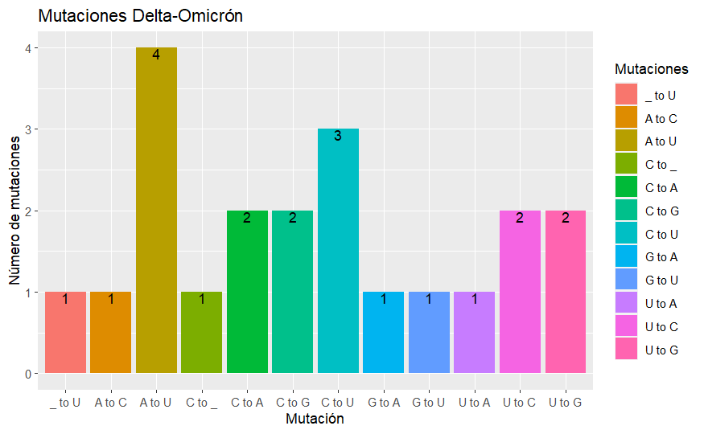

## **Referencias**

- NCBI - WWW Error Blocked Diagnostic. (s. f.). NCBI.NLM.NIH.GOV. Recuperado 1 de mayo de 2022, de https://www.ncbi.nlm.nih.gov/
- Global Virus network. (2021, 22 octubre). Delta (B.1.617.2). GVN. Recuperado 1 de mayo de 2022, de https://gvn.org/covid-19/delta-b-1-617-2/
- Coronavirus. (2020, 10 enero). WHOINT. Recuperado 1 de mayo de 2022, de https://www.who.int/health-topics/coronavirus#tab=tab_1
- Katella, K. (2022, 20 abril). Omicron, Delta, Alpha, and More: What To Know About the Coronavirus Variants. Yale Medicine. Recuperado 1 de mayo de 2022, de https://www.yalemedicine.org/news/covid-19-variants-of-concern-omicron
- Pesheva, B. E. (2022, 3 febrero). Beyond Omicron. Harvard Medical School. Recuperado 1 de mayo de 2022, de https://hms.harvard.edu/news/beyond-omicron